# SP/RM[1]

### Introduction

#### SP/RM[1]

This experiment tests which arrows have most impact depending on the type of monster.

- Repose : The number of shots to kill the monster.
- Conditions :  
  Between Block Factor : Two differnet type of monsters; Bokobolin and Lizard.  
  Block : 6 monsters.  
  Within Block Factor : Three different type of arrows; Arrow, Shock, and Bomb.
- Material : Battle

**The hypothesis is as follows**

$$H_0: \mu_{bokobolin} =\mu_{lizard}$$

$$H_a: \ \text{at least one of the polulation means is different.} \ \mu_{bokobolin} \neq\mu_{lizard}$$

$$H_0: \mu_{arrow} = \mu_{shock} = \mu_{bomb}$$

$$H_a: \ \text{at least one of the polulation means is different.} \ \mu_{arrow} \neq\mu_{shock}\neq\mu_{bomb}$$

**Interaction**
$$H_0: \ \text{No interaction with the betweenblock factor and withinblock factor}$$

$$H_a: \ \text{There is an interaction}$$

**The significant level for the test**
$$\alpha = 0.05$$

**Method**

1. There are 6 types of arrows in the game. Some of the monsters have the resistance of cold, heat, or shock. I didn’t use fire, frozen, and ancient arrows because they can kill a certain monster with one hit. I played the character with a basic armor. I played more than 50 hrs in this game. I also used a basic bow for each experiment.
2. Monster type is the block to reduce the variability. On a piece of paper, write a type and name of the monster, and arrow type with a certain id. Then, use a random generator to determine the order of the experiment.
3. Save the game data before killing the monster so that I can go back to the data after kill the monster - For the same setting for each experiment. The character wears a basic armor that doesn’t have any effect. Also, it shouldn’t be raining in the game (rain affects arrow damage). Each type of temperature requires a particular armor, so I didn’t play in any area that is cold or hot.

4.Perform the experiment with the Bokobolin (3 different Bokobolins) and Lizard (3 different Lizards). Count the number of shots as killing the monster. After the monster dies, go back to the saved file and kill the monster with a different arrow. The order of arrows per each block is also random by the generator.

##### Zelda Data

```r
datatable(zelda2)
```

|  | Monster_type | Monster | Arrow | Hit |
| --- | --- | --- | --- | --- |
| 1 | Bokobolin | 1 | arrow | 2 |
| 2 | Bokobolin | 1 | shock | 2 |
| 3 | Bokobolin | 1 | bomb | 1 |
| 4 | Bokobolin | 2 | arrow | 5 |
| 5 | Bokobolin | 2 | shock | 4 |
| 6 | Bokobolin | 2 | bomb | 3 |
| 7 | Bokobolin | 3 | arrow | 17 |
| 8 | Bokobolin | 3 | shock | 12 |
| 9 | Bokobolin | 3 | bomb | 8 |
| 10 | lizard | 4 | arrow | 2 |

[output cut: 8 more lines]

### Analysis

**SP/RM model**
$$y_{ijk}=\mu +\alpha_{i} +\beta_{j(i)} +\gamma_{k} +(\alpha y)_{ik} +\epsilon _{ijk}, i=1,..6,j=1,2, k=1,2,3$$

$\mu$ = benchmark  
$\alpha_i$ = type of monster  
$\beta_{ji}$ = effect of a monster  
$\gamma_k$ = effect of type of arrow  
$(\alpha y)_{ik}$ = interaction betwwen type of monster and type of arrow  
$\epsilon_{ijk}$ = residual

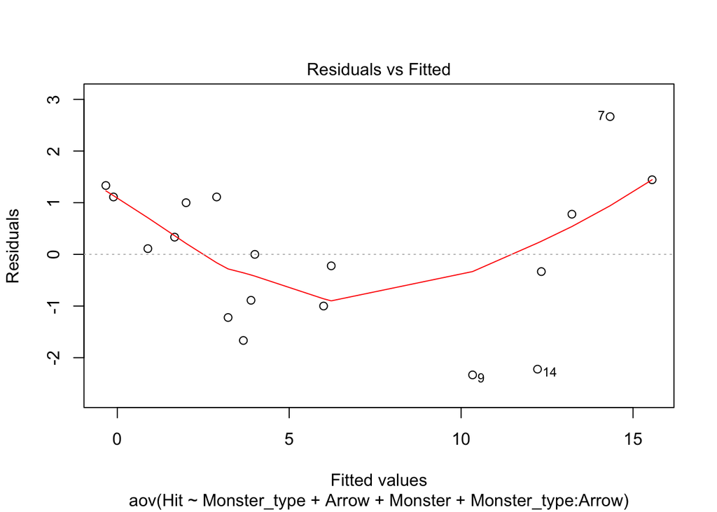

```r
zeldamod <- aov(Hit ~ Monster_type + Arrow + Monster + Monster_type:Arrow, data=zelda2, contrasts = list(Monster_type=contr.sum, Monster=contr.sum, Arrow = contr.sum))
plot(zeldamod, which=1:1)
```

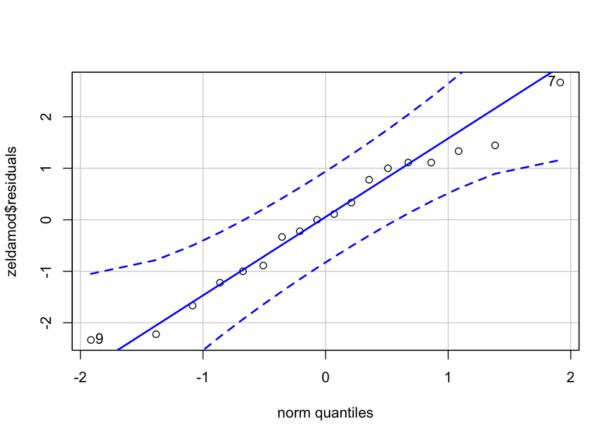

```
## [1] 7 9
```

```r
qqPlot(zeldamod$residuals)
```

```r
favstats(Hit ~ Monster_type, data=zelda2)
```

```
##   Monster_type min Q1 median Q3 max     mean       sd n missing
## 1    Bokobolin   1  2      4  8  17 6.000000 5.385165 9       0
## 2       lizard   1  2      4 10  17 6.444444 5.897269 9       0
```

```r
favstats(Hit ~ Arrow, data=zelda2)
```

```
##   Arrow min   Q1 median    Q3 max     mean       sd n missing
## 1 arrow   2 2.75    5.5 14.25  17 8.166667 7.026142 6       0
## 2  bomb   1 1.50    3.0  6.75  14 5.000000 5.099020 6       0
## 3 shock   1 2.50    4.0  8.50  12 5.500000 4.460942 6       0
```

Residual vs. Fitted graph looks okay. Double checked with favstats. The smallest standard deviation *3 is larger than the biggest standard deviation. Also, QQ-Plot looks good since all dots are inside of boundaries.

```r
pander(anova(zeldamod))
```

Analysis of Variance Table

|  | Df | Sum Sq | Mean Sq | F value | Pr(>F) |
| --- | --- | --- | --- | --- | --- |
| **Monster_type** | 1 | 0.8889 | 0.8889 | 0.2238 | 0.6488 |
| **Arrow** | 2 | 34.78 | 17.39 | 4.378 | 0.05197 |
| **Monster** | 4 | 436.9 | 109.2 | 27.5 | 9.995e-05 |
| **Monster_type:Arrow** | 2 | 6.778 | 3.389 | 0.8531 | 0.4615 |
| **Residuals** | 8 | 31.78 | 3.972 | NA | NA |

#### Checking

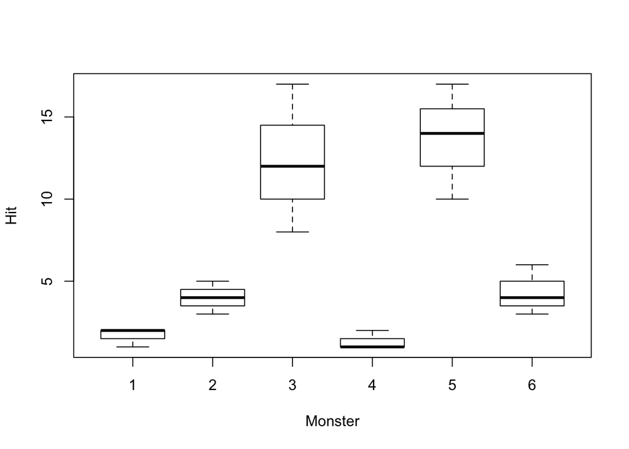

```r
boxplot(Hit~ Monster, data=zelda2)
```

Monster 3 and monster 5 are hard to kill than other monsters. They are high-level monsters.

### Conclusion

There is no interaction between the arrow and the monster type. In other words, there won’t be a significant difference in killing the Bokobolin monster or Lizard monster with any type of arrow.

### Images

[figure not shown]

[figure not shown]

[figure not shown]

[figure not shown]

[figure not shown]

[figure not shown]

[figure not shown]